# A summary of the tweets generated at the ICCB-ECCB 2015 meeting

Joona Lehtomäki

## About this document

The code generating this documents was originally developed by François Michonneau (fmic_) for [2015 Evolution conference](http://evolution2015.org/). Here, it’s adapted for ICCB-ECCB 2015 with very minor changes by Joona Lehtomäki (jlehtoma).

This document was generated using RMarkdown, and the source is available on GitHub at: https://github.com/jlehtoma/iccb2015-tweets (forked from https://github.com/fmichonneau/evol2015-tweets).

Pull requests to add other figures or fix bugs are welcome.

The dataset accumulated during the conference is available as a CSV file from figshare: http://dx.doi.org/10.6084/m9.figshare.1506667.

This document (and associated code) is released under a [CC0 licence](https://creativecommons.org/publicdomain/zero/1.0/).

All questions and comments very welcome, just ping jlehtoma or fmic_ (original author) on Twitter.

## Basic summary

Last update time: 2015-08-10 13:05:01.

| Description | n |
| --- | --- |
| Tweets with the `#ICCB2015` hashtag between July 22nd and August 10th: | 17037 |
| Original tweets (no retweets): | 6680 |
| Users who tweeted: | 2063 |

## The 5 most favorited tweets

> Honoured (and surprised) to be awarded Oceania Best Student Presentation at #ICCB2015. Thank you @SCBOceania et al. http://t.co/PiyAsw7kc2

> — TimDoherty_ | [2015-08-06](https://twitter.com/TimDoherty_/status/629330738635243520) | 9 retweets, 32 favorites.

> The most critical information you’ll need all week: wifi password at Le Corum! #ICCB2015 http://t.co/qLb7N16eOB

> — ICCB_ECCB | [2015-08-02](https://twitter.com/ICCB_ECCB/status/627771985246965760) | 19 retweets, 18 favorites.

> For more thoughtful takes on this debate, I highly recommend @htallis http://t.co/1ptIwyLqag & @nijhuism http://t.co/pNDwb1owEi #iccb2015

> — AmandaConsSci | [2015-08-04](https://twitter.com/AmandaConsSci/status/628601334703517696) | 10 retweets, 17 favorites.

> Holy alpine geomorphology!! Glorious views of Alps & glaciers on my post #ICCB2015 flight from Barcelona to Munich http://t.co/rLEClRYy08

> — mtbogan | [2015-08-09](https://twitter.com/mtbogan/status/630359198526615552) | 4 retweets, 17 favorites.

> My apologies to those who enjoyed #ICCB2015, but I was really upset by what happened tonight. We MUST #walkthewalk. https://t.co/bTlnx1Wa5s

> — fromdolphview | [2015-08-06](https://twitter.com/fromdolphview/status/629415985011933185) | 12 retweets, 16 favorites.

## The 5 most retweeted tweets

> Your conference presentation: How you planned it vs. how it actually goes (by @phdcomics) #ICCB2015 http://t.co/yX18saCUqh

> — conservbytes | [2015-08-03](https://twitter.com/conservbytes/status/628083593995268096) | 30 retweets, 15 favorites.

> @HugePossum says young conservation biologists should not take advice from old grey men as they may make you stagnant. #ICCB2015 @ARC_CEED

> — MorenaMills | [2015-08-04](https://twitter.com/MorenaMills/status/628525986351611904) | 23 retweets, 15 favorites.

> The most critical information you’ll need all week: wifi password at Le Corum! #ICCB2015 http://t.co/qLb7N16eOB

> — ICCB_ECCB | [2015-08-02](https://twitter.com/ICCB_ECCB/status/627771985246965760) | 19 retweets, 18 favorites.

> Urgently needed for #ICCB2015 ! volunteers !!! Over 100 volunteers dropped out. Contact lcugniere@conbio.org if you can help

> — Craken_MacCraic | [2015-08-01](https://twitter.com/Craken_MacCraic/status/627504125232705536) | 18 retweets, 4 favorites.

> Any macroecologists at #ICCB2015 or #ESA2015/#ESA100? I’m giving away data on seabird body size geographic var’n! https://t.co/Tc5Pqh5LxW

> — thelabandfield | [2015-08-04](https://twitter.com/thelabandfield/status/628637575578841088) | 16 retweets, 2 favorites.

## Top tweeters

All generated tweets (including retweets)

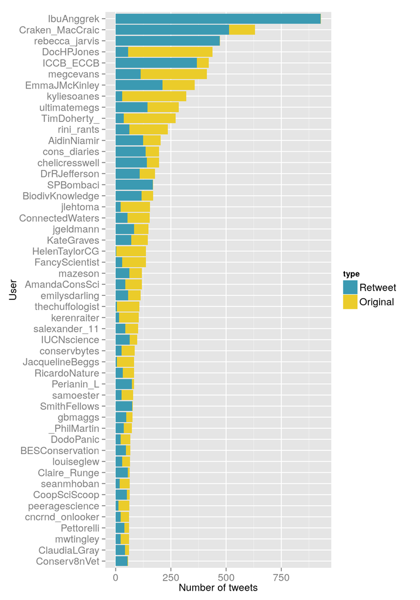

Only for original tweets (retweets excluded)

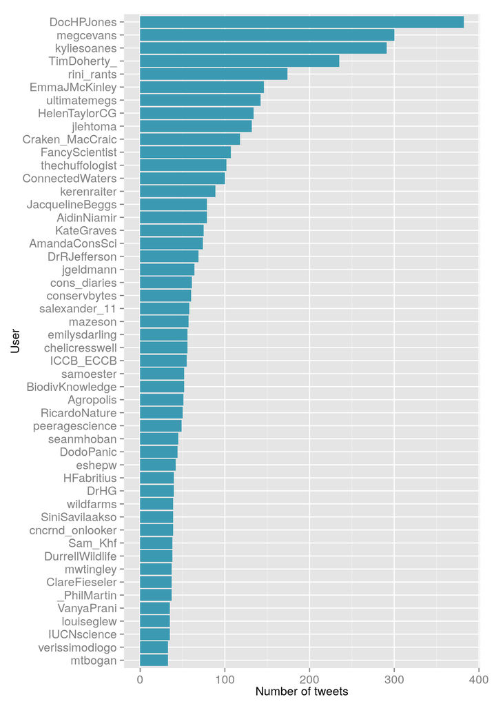

## Most favorited/retweeted users

The figures below only include users who tweeted 5+ times, and don’t include retweets.

### Number of favorites received by users

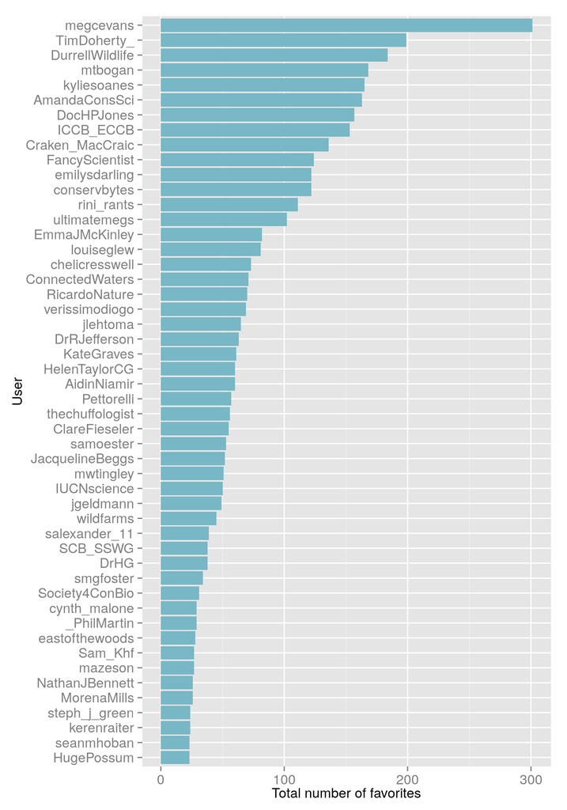

### Number of retweets received by users

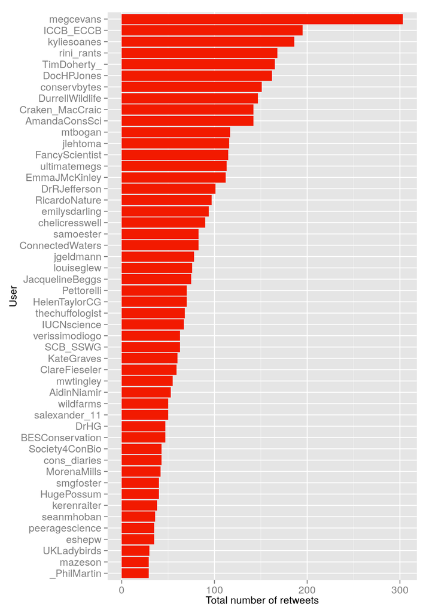

### Mean numbers of favorites received

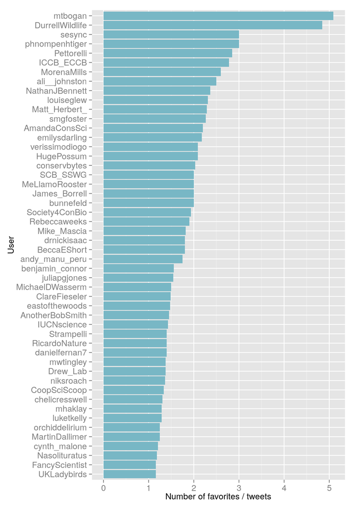

### Mean numbers of retweets received

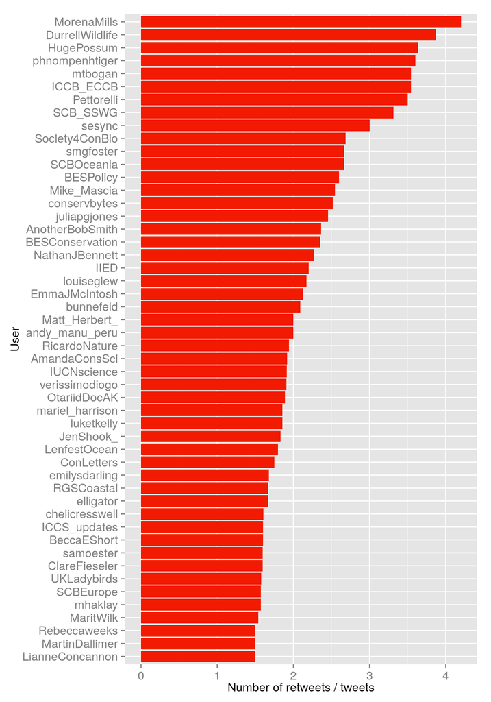

## Word cloud

The top 100 words among the original tweets.

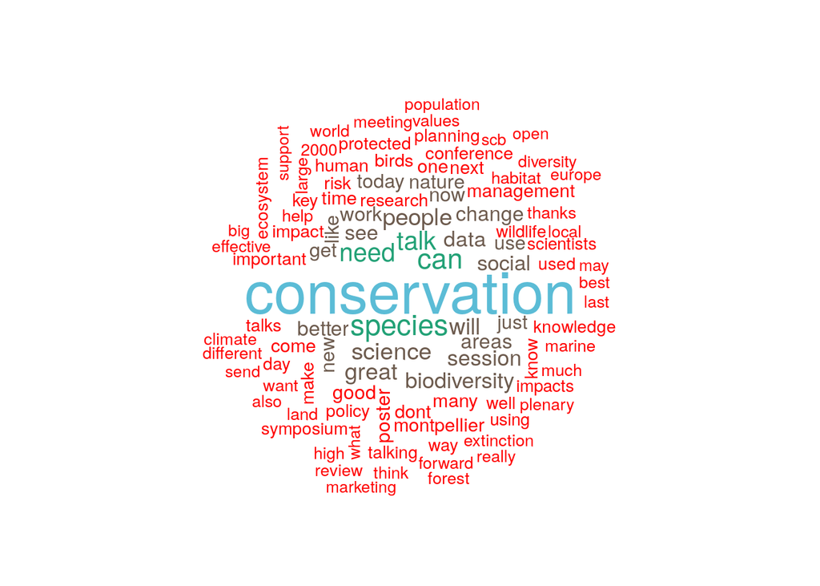

To the extent possible under law, [Joona Lehtomäki](https://github.com/jlehtoma/iccb2015-tweets) has waived all copyright and related or neighboring rights to Summary of tweets at the ICCB-ECCB 2015 conference. This work is published from: Finland.